# Introduction to Validate

Mark van der Loo and Edwin de Jonge

August 27, 2015

### Introduction

The validate package is intended to make checking your data easy, maintainable and reproducible. The package allows you to

- Test your data set(s) against predefined rules, either in- or cross-data set
- Import and export rule sets from structured or free-format files
- Investigate and visualize the results of a data validation step
- Do basic rule maintenance tasks

There are a few nouns related to the infrastructure offered by validate,

- data set: your data
- `validator` an object representing a set of rules your data must satisfy
- `confrontation` an object representing the results of confronting data with rules

There is also a single verb, namely

- `confront`: evaluate the validation rules in the context of one or more data sets.

### A quick example

Here’s an example demonstrating the typical workflow. We’ll use the built-in `women` data set (average heights and weights for American women aged 30-39).

```r
data(women)
summary(women)
```

```
##      height         weight
##  Min.   :58.0   Min.   :115.0
##  1st Qu.:61.5   1st Qu.:124.5
##  Median :65.0   Median :135.0
##  Mean   :65.0   Mean   :136.7
##  3rd Qu.:68.5   3rd Qu.:148.0
##  Max.   :72.0   Max.   :164.0
```

Validating data is all about checking whether a data set meets presumptions or expectations you have about it, and the validate package makes it easy for you to define those expectations. Let’s do a quick check on variables in the `women` data set.

```r
library(validate)
cf <- check_that(women, height > 0, weight > 0, height/weight > 0.5)
summary(cf)
```

```
##   rule items passes fails nNA error warning          expression
## 1   V1    15     15     0   0 FALSE   FALSE          height > 0
## 2   V2    15     15     0   0 FALSE   FALSE          weight > 0
## 3   V3    15      2    13   0 FALSE   FALSE height/weight > 0.5
```

`check_that` returns an object containing all sorts of information on the validation results. The easiest way to check the results is with `summary`, which returns a `data.frame` with the following basic information:

If you’re a fan of the pipe-operator provided by the magrittr, the above statement can also be performed as follows.

```r
women %>% check_that(height > 0, weight > 0, height/weight > 0.5) %>% summary()
```

The same information can be summarized graphically as well.

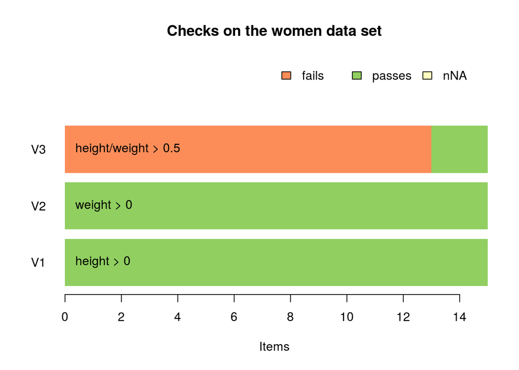

```r
barplot(cf,main="Checks on the women data set")
```

### Validator objects

Validator objects are used to store, investigate and manipulate rule sets.

```r
v <- validator(height > 0, weight > 0, height/weight > 0)
v
```

```
## Object of class 'validator' with 3 elements:
##  V1: height > 0
##  V2: weight > 0
##  V3: height/weight > 0
```

The validator object has stored the rule and assigned names to them for future reference. To check this, we confront the data set with the validation rules we’ve just defined:

```r
cf <- confront(women,v)
cf
```

```
## Object of class 'validation'
## Call:
##     confront(x = women, dat = v)
##
## Confrontations: 3
## With fails    : 0
## Warnings      : 0
## Errors        : 0
```

The object `cf` contains the result of checking the data in `women` against the expectations in `v`. The fact that there are no warnings or errors means that indeed each rule could be evaluated successfully (an error would occur for example, if we’d misspell height). Now let’s take a look at the actual results.

```r
summary(cf)
```

```
##   rule items passes fails nNA error warning        expression
## 1   V1    15     15     0   0 FALSE   FALSE        height > 0
## 2   V2    15     15     0   0 FALSE   FALSE        weight > 0
## 3   V3    15     15     0   0 FALSE   FALSE height/weight > 0
```

Now, suppose that we expect that the BMI (weight divided by height squared) of each item to be below 23. We need to express the weight in kg and the height in meters, so the equation for BMI becomes
$$BMI = \frac{weight\times0.45359}{(height\times0.0254)^2}$$
Moreover, assume that we suspect that the average BMI is between 22 and 22.5. Let’s create another validator object that first computes the BMI and next tests whether the BMI values conform to our suspicion.

```r
v <- validator(
  BMI := (weight*0.45359)/(height*0.0254)^2
  , height > 0
  , weight > 0
  , BMI < 23
  , mean(BMI) > 22 & mean(BMI) < 22.5
)
v
```

```
## Object of class 'validator' with 5 elements:
##  V1: `:=`(BMI, (weight * 0.45359)/(height * 0.0254)^2)
##  V2: height > 0
##  V3: weight > 0
##  V4: BMI < 23
##  V5: mean(BMI) > 22 & mean(BMI) < 22.5
```

Checking is easy as before:

```r
cf <- confront(women,v)
summary(cf)
```

```
##   rule items passes fails nNA error warning
## 1   V2    15     15     0   0 FALSE   FALSE
## 2   V3    15     15     0   0 FALSE   FALSE
## 3   V4    15     10     5   0 FALSE   FALSE
## 4   V5     1      0     1   0 FALSE   FALSE
##                                                                                                    expression
## 1                                                                                                  height > 0
## 2                                                                                                  weight > 0
## 3                                                               ((weight * 0.45359)/(height * 0.0254)^2) < 23
## 4 mean(((weight * 0.45359)/(height * 0.0254)^2)) > 22 & mean(((weight * 0.45359)/(height * 0.0254)^2)) < 22.5
```

Observe that the expressions for validation are now manipulated: everywhere where `BMI` was used, it was replaced with the computation defined before.

### Confrontation objects

The outcome of confronting a validator object with a data set is an object of class `confrontation`. There are several ways to extract information from a `confrontation` object.

- `summary`: summarize output; returns a `data.frame`
- `aggregate`: aggregate validation in several ways
- `sort` : aggregate and sort in several ways
- `values`: Get the values in an array, or a list of arrays if rules have different output dimension structure
- `errors`: Retrieve error messages caught during the confrontation
- `warnings`: Retrieve warning messages caught during the confrontation.

By default aggregates are produced by rule.

```r
cf <- check_that(women, height>0, weight>0,height/weight < 0.5)
aggregate(cf)
```

```
##    npass nfail nNA rel.pass rel.fail rel.NA
## V1    15     0   0      1.0      0.0      0
## V2    15     0   0      1.0      0.0      0
## V3    12     3   0      0.8      0.2      0
```

To aggregate by record, use `by='record'`

```r
head(aggregate(cf,by='record'))
```

```
##   npass nfail nNA  rel.pass  rel.fail rel.NA
## 1     2     1   0 0.6666667 0.3333333      0
## 2     2     1   0 0.6666667 0.3333333      0
## 3     2     1   0 0.6666667 0.3333333      0
## 4     3     0   0 1.0000000 0.0000000      0
## 5     3     0   0 1.0000000 0.0000000      0
## 6     3     0   0 1.0000000 0.0000000      0
```

Aggregated results can be automatically sorted, so records with the most violations or rules that are violated most sort higher.

```r
# rules with most violations sorting first:
sort(cf)
```

```
##    npass nfail nNA rel.pass rel.fail rel.NA
## V3    12     3   0      0.8      0.2      0
## V1    15     0   0      1.0      0.0      0
## V2    15     0   0      1.0      0.0      0
```

Confrontation objects can be subsetted with single bracket operators (like vectors), to obtain a sub-object pertaining only to the selected rules.

```
summary(cf[c(1,3)])
```

### Confrontation options

By default, all errors and warnings are caught when validation rules are confronted with data. This can be switched off by setting the `raise` option to `"errors"` or `"all"`, e.g. here, the error is caught,

```r
v <- validator(hite > 0, weight>0)
summary(confront(women, v))
```

```
##   rule items passes fails nNA error warning expression
## 1   V1     0      0     0   0  TRUE   FALSE   hite > 0
## 2   V2    15     15     0   0 FALSE   FALSE weight > 0
```

while here it is raised immediately.

```r
# this gives an error
confront(women, v, raise='all')
```

### Investigating validator objects

Validator objects store a set of rules, optionally with some metadata per rule. Currently, the following functions can be used to get or set metadata:

- `origin` : Where was a rule defined?
- `names` : The name per rule
- `created` : when were the rules created?
- `label` : Short description of the rule
- `description`: Long description of the rule

Names can be set from the command line when defining a validator object.

```r
v <- validator(rat = height/weight > 0.5, htest=height>0, wtest=weight > 0)
names(v)
```

```
## [1] "rat"   "htest" "wtest"
```

Also try

```r
names(v)[1] <- "ratio"
v
```

```
## Object of class 'validator' with 3 elements:
##  ratio: height/weight > 0.5
##  htest: height > 0
##  wtest: weight > 0
```

Some general information is obtained with `summary`,

```r
summary(v)
```

```
##   block nvar rules linear
## 1     1    2     3      2
```

Here, some properties per *block* of rules is given. Two rules occur in the same block if when they share a variable. In this case, all rules occur in the same block.

and the number of rules can be requested with `length`

```
length(v)
```

With `variables`, the variables occurring per rule, or over all the rules can be requested.

```r
variables(v)
```

```
## [1] "height" "weight"
```

```r
variables(v,as="matrix")
```

```
##        variable
## rule    height weight
##   ratio   TRUE   TRUE
##   htest   TRUE  FALSE
##   wtest  FALSE   TRUE
```

Validator objects can be subsetted as if they were lists using the single and double bracket operators.

```r
v[c(1,3)]
```

```
## Object of class 'validator' with 2 elements:
##  ratio: height/weight > 0.5
##  wtest: weight > 0
## Options:
## raise: none; lin.eq.eps: 1e-08; na.value: NA; sequential: TRUE; na.condition: FALSE
```

```r
v['ratio','wtest']
```

```
## Object of class 'validator' with 1 elements:
##  ratio: height/weight > 0.5
## Options:
## raise: none; lin.eq.eps: 1e-08; na.value: NA; sequential: TRUE; na.condition: FALSE
```

The double bracket can be used to inspect a single rule

```r
v[[1]]
```

```
##
## Object of class rule.
##  expr       : height/weight > 0.5
##  name       : ratio
##  label      :
##  description:
##  origin     : command-line
##  created    : 2017-04-07 22:23:48
```

### Validator objects and confrontation objects are reference objects

As simple as that. If you do

```
w <- v
```

for a validator object `v`, then `w` just points to the same physical object as `v`. To make an actual copy, you can select everything.

```
w <- v[]
```